# Basic Statistics Refresher with R

Clay Ford, Statistical Research Consultant, UVA Library

## Quick Intro to R Notebooks and R Markdown

To hide the output, click the Expand/Collapse output button. To clear results (or an error), click the “x”.

You can also press *Ctrl+Enter* (Win/Linux) or *Cmd+Return* (Mac) to run one line of code at a time (instead of the entire chunk).

Add a new R code chunk by clicking the *Insert Chunk* button on the toolbar or by pressing *Ctrl+Alt+I* (Win/Linux) or *Cmd+Option+I* (Mac).

## Code Along 0

Insert a new R code chunk below and type/run the code: 22/7

## Load packages

The magrittr package provides us with a “pipe” function: `%>%`

We will use this function to send the results of one function into the first argument of the next function. If that doesn’t make sense, don’t worry, it will!

## Load data

Today we’ll work with a sample of the 2012 US Census American Community Survey. (https://www.census.gov/programs-surveys/acs). I obtained this data from the openintro package, which accompanies the OpenIntro Statistics textbook: https://www.openintro.org/book/os/

Strictly speaking, this is *not* a simple random sample, which is assumed when performing inferential statistics at the introductory level. However we will treat it as such for the purposes of today’s class since it provides us one versatile, easy-to-understand data set to demonstrate multiple statistical methods.

The following code imports the acs12.csv file; the result is a data frame.

The `str()` function shows us the structure of the data frame. The names following the `$` are the column or variable names. “int” means integer. “chr” means character. Our data has 2000 observations and 13 variables. “NA” means “Not Available” (ie, missing).

```r
str(acs12)
```

```
'data.frame':   2000 obs. of  13 variables:
 $ income      : int  60000 0 NA 0 0 1700 NA NA NA 45000 ...
 $ employment  : chr  "not in labor force" "not in labor force" NA "not in labor force" ...
 $ hrs_work    : int  40 NA NA NA NA 40 NA NA NA 84 ...
 $ race        : chr  "white" "white" "white" "white" ...
 $ age         : int  68 88 12 17 77 35 11 7 6 27 ...
 $ gender      : chr  "female" "male" "female" "male" ...
 $ citizen     : chr  "yes" "yes" "yes" "yes" ...
 $ time_to_work: int  NA NA NA NA NA 15 NA NA NA 40 ...
 $ lang        : chr  "english" "english" "english" "other" ...
 $ married     : chr  "no" "no" "no" "no" ...
 $ edu         : chr  "college" "hs or lower" "hs or lower" "hs or lower" ...
 $ disability  : chr  "no" "yes" "no" "no" ...
 $ birth_qrtr  : chr  "jul thru sep" "jan thru mar" "oct thru dec" "oct thru dec" ...
```

You can also click on the name in the Environment window to view the data.

To get a quick summary of one of the numeric columns, use `summary`:

```r
summary(acs12$income)
```

```
   Min. 1st Qu.  Median    Mean 3rd Qu.    Max.    NA's
      0       0    3000   23600   33700  450000     377
```

To get a quick summary of one of the character columns, use `table`:

```r
table(acs12$employment)
```

```
          employed not in labor force         unemployed
               843                656                106
```

## Code Along 1

Summarize the “edu” and “time_to_work” columns.

Add a new R code chunk by pressing *Ctrl+Alt+I* (Win/Linux) or *Cmd+Option+I* (Mac).

```r
table(acs12$edu)
```

```
    college        grad hs or lower
        359         144        1439
```

## Estimating proportions with confidence intervals

It is commonly of interest to know what portion of the whole some count represents. For example:

- what proportion of the population works more than 40 hours a week?
- What proportion earns more than $100,000/year?
- What proportion reports being “unemployed”?

One easy way to find a specific proportion is to take the `mean` of a TRUE/FALSE result. In R, TRUE = 1, FALSE = 0. The mean of zeroes and ones is the proportion of ones, and hence the proportion of TRUEs.

R’s comparison operators:

- == EQUAL
- != NOT EQUALS
- > GREATER THAN
- < LESS THAN
- > = GREATER THAN OR EQUAL
- <= LESS THAN OR EQUAL

For example, what proportion of the population reports speaking a language besides English at home?

What are the options?

```r
table(acs12$lang)
```

```
english   other
   1527     368
```

To get the proportion who speak “other”, we can use the `mean` function.

```r
mean(acs12$lang == "other")
```

```
[1] NA
```

We get NA because we have missing values in the “lang” column. That’s a feature, not a bug. It alerts us that we have missing data. To override, set `na.rm = TRUE` to remove the NA values.

```r
mean(acs12$lang == "other", na.rm = TRUE)
```

```
[1] 0.1941953
```

So about 19%.

How certain is that estimate? Another sample would give us a slightly different result. *Confidence intervals help us quantify the uncertainty.* They provide an estimated lower and upper bound of our estimate.

The `prop.test()` function returns a 95% confidence interval for an estimated proportion. It requires number of “successes” (ie, number who reported “other”) and total number of “trials” (ie, number of respondents who answered the question).

```r
table(acs12$lang)
```

```
english   other
   1527     368
```

The `x` argument takes number of successes. The `n` argument takes number of trials or observations.

```r
prop.test(x = 368, n = 1527 + 368)
```

```
    1-sample proportions test with continuity correction

data:  368 out of 1527 + 368, null probability 0.5
X-squared = 707.63, df = 1, p-value < 2.2e-16
alternative hypothesis: true p is not equal to 0.5
95 percent confidence interval:
 0.1767565 0.2128897
sample estimates:
        p
0.1941953
```

The reported 95% confidence interval is about (0.18, 0.21). We’ll talk about the p-value and alternative hypothesis later in the workshop. For this question it’s not relevant.

Above we manually typed the numbers, which is an opportunity to make a mistake. Here’s one way to avoid that. Calculate the number who answered “other” and the number of non-missing responses to the “lang” question.

```r
prop.test(x = other, n = N)
```

```
    1-sample proportions test with continuity correction

data:  other out of N, null probability 0.5
X-squared = 707.63, df = 1, p-value < 2.2e-16
alternative hypothesis: true p is not equal to 0.5
95 percent confidence interval:
 0.1767565 0.2128897
sample estimates:
        p
0.1941953
```

The mosaic version of `prop.test` allows us to simply use a conditional expression. (Note: placing the package name and two colons before a function tells R to use the function in that package.)

```r
mosaic::prop.test(acs12$lang == "other")
```

```
    1-sample proportions test with continuity correction

data:  ==  [with success = TRUE]acs12$lang  [with success = TRUE]other  [with success = TRUE]
X-squared = 707.63, df = 1, p-value < 2.2e-16
alternative hypothesis: true p is not equal to 0.5
95 percent confidence interval:
 0.1767565 0.2128897
sample estimates:
        p
0.1941953
```

Another example: what proportion of people work more than 50 hours/week?

```r
mosaic::prop.test(acs12$hrs_work > 50)
```

```
    1-sample proportions test with continuity correction

data:  >  [with success = TRUE]acs12$hrs_work  [with success = TRUE]50  [with success = TRUE]
X-squared = 657.39, df = 1, p-value < 2.2e-16
alternative hypothesis: true p is not equal to 0.5
95 percent confidence interval:
 0.06894864 0.10546707
sample estimates:
         p
0.08550574
```

About 0.09, with 95% CI of (0.07, 0.11).

## Code Along 2

Estimate the proportion of the population that earns more than $100,000/year along with a confidence interval.

Add a new R code chunk by pressing *Ctrl+Alt+I* (Win/Linux) or *Cmd+Option+I* (Mac).

```r
mosaic::prop.test(acs12$income > 100000)
```

```
    1-sample proportions test with continuity correction

data:  >  [with success = TRUE]acs12$income  [with success = TRUE]1e+05  [with success = TRUE]
X-squared = 1371.6, df = 1, p-value < 2.2e-16
alternative hypothesis: true p is not equal to 0.5
95 percent confidence interval:
 0.03127331 0.05106706
sample estimates:
         p
0.04004929
```

## Estimating means with confidence intervals

Means are one measure of the “center” of data. It is often interpreted as “expected value”. For example, if we took the mean of the income column of our data, we might interpret it as the expected value of someone’s income if we randomly sampled them from the population. This interpretation can be flawed, however, particularly if our data is skewed. Nevertheless, the mean is the mean. Just because it’s not a good measure of expected value doesn’t mean it’s wrong. It just may not tell the whole story.

Another measure of center is the median. That’s the literal middle of the data: 50% on one side, 50% on the other. It’s called an “order statistic”. Sometimes it’s a better representation of “expected value”, especially when it comes to quantities like income where the distribution can be quite skewed.

One way to quickly visualize distributions of numeric data is to use the `hist` function.

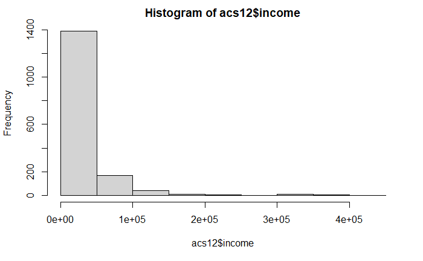

This is textbook skew!

Again, the summary function is useful for investigating the distribution of a quantity:

```r
summary(acs12$income)
```

```
   Min. 1st Qu.  Median    Mean 3rd Qu.    Max.    NA's
      0       0    3000   23600   33700  450000     377
```

This tells us at least 25% of our data is 0. “1st Qu.” is the first quartile, or the lower 25% of the data. There’s also a huge difference between the Median and the Mean.

Let’s go ahead and calculate the confidence interval for mean income. We can do this pretty easily with the `t.test` function. Simply give it a column of numeric data from a data frame.

```r
t.test(acs12$income)
```

```
    One Sample t-test

data:  acs12$income
t = 20.417, df = 1622, p-value < 2.2e-16
alternative hypothesis: true mean is not equal to 0
95 percent confidence interval:
 21332.76 25867.20
sample estimates:
mean of x
 23599.98
```

The 95% CI is about (21332, 25867). Again the hypothesis test results are irrelevant.

## Code Along 3

Estimate the mean time_to_work (ie, commute time) with a 95% confidence interval. Take a look at the distribution as well.

Add a new R code chunk by pressing *Ctrl+Alt+I* (Win/Linux) or *Cmd+Option+I* (Mac).

```r
t.test(acs12$time_to_work)
```

```
    One Sample t-test

data:  acs12$time_to_work
t = 32.635, df = 782, p-value < 2.2e-16
alternative hypothesis: true mean is not equal to 0
95 percent confidence interval:
 24.43369 27.56120
sample estimates:
mean of x
 25.99745
```

## Comparing two proportions

The following code creates a two-way contingency table with gender in the rows and employment in the columns using `xtabs`. The table is then “piped” into the `proportions` function. The argument `margin=1` says to calculate proportions along the rows. The result says about 6% of females are unemployed and that about 7% of males are unemployed. That’s a difference of 1%.

The `%>%` operator can be entered in RStudio using the following keyboard shortcuts:

- Ctrl + Shift + M (Win/Linux)
- Cmd + Shift + M (Mac)

```r
xtabs(~ gender + employment, data = acs12) %>%
  proportions(margin = 1)
```

```
        employment
gender    employed not in labor force unemployed
  female 0.4703657          0.4703657  0.0592686
  male   0.5788177          0.3485222  0.0726601
```

Is this difference real? If we took another sample, would we get a similar result? Or might it flip and show more females being unemployed?

This is where *hypothesis testing* can be useful. Two competing hypotheses:

- Null: no difference between proportions
- Alternative: the proportions are different

To execute a hypothesis test comparing two proportions we can use the `prop.test` function. The first argument is the number of “successes” or occurrences. The second argument is the number of “trials” or observed responses.

Number of females and males reporting unemployed are 47 and 59, respectively. The total number of *observed* females and males who reported employment status is 793 and 812, respectively. Below we use the `addmargins` function to get row and column totals.

```r
xtabs(~ gender + employment, data = acs12) %>%
  addmargins()
```

```
        employment
gender   employed not in labor force unemployed  Sum
  female      373                373         47  793
  male        470                283         59  812
  Sum         843                656        106 1605
```

Now we have the values we need to perform the hypothesis test. Notice the values need to be entered as a *vector*, which we create with the `c()` function.

```r
prop.test(x = c(47, 59), n = c(793, 812))
```

```
    2-sample test for equality of proportions with continuity correction

data:  c(47, 59) out of c(793, 812)
X-squared = 0.95942, df = 1, p-value = 0.3273
alternative hypothesis: two.sided
95 percent confidence interval:
 -0.03890424  0.01212125
sample estimates:
   prop 1    prop 2
0.0592686 0.0726601
```

The p-value says there’s about a 33% chance of getting a difference bigger than than what we observed (about 0.01) if there really is no difference between the proportions.

Traditionally we judge a difference “significant” if the p-value is small, say below 0.05.

In this case, we might conclude:

- “with the current sample size the data were unable to overcome the supposition of no difference in the proportions”

The 95 percent confidence interval is on the difference of proportions. Since it overlaps 0 we’re uncertain about the direction of the difference.

Notice we hard-coded the numbers into the function. There’s nothing wrong with this but provides an opportunity for human error. Here’s one way to avoid that.

```r
# run prop.test with X and N
prop.test(x = X, n = N)
```

```
    2-sample test for equality of proportions with continuity correction

data:  X out of N
X-squared = 0.95942, df = 1, p-value = 0.3273
alternative hypothesis: two.sided
95 percent confidence interval:
 -0.03890424  0.01212125
sample estimates:
   prop 1    prop 2
0.0592686 0.0726601
```

## Code Along 4

About 20% of people with no disability report having a college degree. Likewise, About 12% of people with a disability report having a college degree. Perform a hypothesis test to compare the proportions.

```r
xtabs(~ disability + edu, data = acs12) %>%
  proportions(margin = 1)
```

```
          edu
disability    college       grad hs or lower
       no  0.19827054 0.08153181  0.72019765
       yes 0.11764706 0.03715170  0.84520124
```

```r
xtabs(~ disability + edu, data = acs12) %>%
  addmargins()
```

```
          edu
disability college grad hs or lower  Sum
       no      321  132        1166 1619
       yes      38   12         273  323
       Sum     359  144        1439 1942
```

## Comparing two means

The following code computes the mean hours worked per week for married and non-married people. The `aggregate` function uses the formula interface like `xtabs`. On the left of the `~` we enter the numeric variable. On the right we enter the grouping variable. The final argument is the function we wish to use with aggregate. In this case it’s the mean. Married people appear to work longer hours, by about 5 hours.

| married | hrs_work |
| --- | --- |
| no | 34.97653 |
| yes | 40.37523 |

Is this difference real? If we took another sample, would we get a similar result? Or might it flip and show more single people working more hours?

Again hypothesis testing can help us assess this difference. To execute a hypothesis test comparing two means we can use the `t.test` function. Like `aggregate` we can use the formula interface.

```r
t.test(hrs_work ~ married, data = acs12)
```

```
    Welch Two Sample t-test

data:  hrs_work by married
t = -6.2164, df = 873.23, p-value = 7.874e-10
alternative hypothesis: true difference in means between group no and group yes is not equal to 0
95 percent confidence interval:
 -7.103233 -3.694184
sample estimates:
 mean in group no mean in group yes
         34.97653          40.37523
```

The p-value is virtually 0. There is almost no chance of seeing a difference in means bigger than what we observed if there truly was no difference in the population.

The 95% confidence interval is on the difference of the means. *It is more informative than the p-value*. It provides information on the direction and magnitude of the difference. The p-values does not provide this information. The 95% CI is (-7.1, -3.7). It appears that married people work at least 3.7 hours more per week than non-married people.

Note: Be cautious before concluding that being married *causes* someone to work longer hours. This simple hypothesis test looked at everyone of all ages working full-time and part-time. Perhaps if we compared hours worked between married and non-married people *among full-time workers* we would see a different result.

## Code Along 5

Calculate mean hours worked per week for males and females (gender). Perform a hypothesis test to compare the means.

Add a new R code chunk by pressing *Ctrl+Alt+I* (Win/Linux) or *Cmd+Option+I* (Mac).

## Checking for association between categorical variables

Was race associated with education in 2012? In other words, does knowing race provide some indication of level of education achievement? Let’s look at the cross-tabulation with proportions along the rows (race):

```r
xtabs(~ race + edu, data = acs12) %>%
  proportions(margin = 1) %>%
  round(2)
```

```
       edu
race    college grad hs or lower
  asian    0.26 0.13        0.62
  black    0.13 0.05        0.82
  other    0.08 0.06        0.86
  white    0.20 0.08        0.73
```

A common test for association between categorical variables is the chi-square test. The null is no association. A small p-value provides evidence against the hypothesis of no association. Use the `chisq.test` function with a table to perform a chi-square test.

```r
chisq.test(tab)
```

```
    Pearson's Chi-squared test

data:  tab
X-squared = 27.477, df = 6, p-value = 0.0001179
```

The output is minimal. The small p-value provides evidence that some association is present. But where is it? How strong is it? Which race has higher or lower levels of education than would be expected if there was no association?

One way to check this is to look at the “residuals”. Any cell higher than 2 in absolute value is a place of “strain” or “interest”

```r
ct$residuals
```

```
       edu
race       college       grad hs or lower
  asian  1.5303730  1.8307309  -1.3435175
  black -1.7262846 -1.4671986   1.3263722
  other -2.8853197 -0.5549533   1.6167079
  white  1.1543453  0.2653434  -0.6605088
```

People who identified race as “other” seem to have a lower rate of “college” education than expected.

A visual way to assess this is with a mosaic plot. Use the `mosaicplot` function on the table and set `shade = TRUE`. Red spots indicate cell counts that are lower than expected, blue spots indicate cell counts that higher than expected.

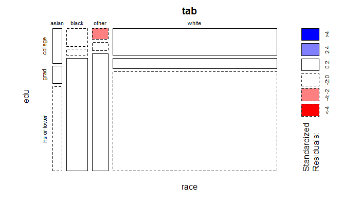

Note: Small cell counts (less than 5) can lead to warnings that say “Chi-squared approximation may be incorrect”. When that happens we’re basically being told “beware, you have a small amount of data.”

## Code Along 6

Is race associated with employment? If so, how so?

Add a new R code chunk by pressing *Ctrl+Alt+I* (Win/Linux) or *Cmd+Option+I* (Mac).

## Checking for association between numeric variables

Is the hours worked per week associated with income? Association of two numeric variables is sometimes measured with correlation. Formally, correlation measures *linear* association and ranges from -1 to 1.

This illustration is useful: https://en.wikipedia.org/wiki/Correlation_and_dependence#/media/File:Correlation_examples2.svg

The `cor.test` function calculates correlation and performs a hypothesis test to check if it’s plausibly different from 0. More importantly it returns a 95% confident interval to help us gauge the uncertainty in our estimate. It allows the use of a formula interface similar to `xtabs`. Nothing goes to the left of the `~`

```r
cor.test(~ hrs_work + income, data = acs12)
```

```
    Pearson's product-moment correlation

data:  hrs_work and income
t = 11.254, df = 957, p-value < 2.2e-16
alternative hypothesis: true correlation is not equal to 0
95 percent confidence interval:
 0.2847379 0.3966019
sample estimates:
      cor
0.3418804
```

Correlation is estimated to be about 0.34 with a 95% CI of (0.28, 0.40). It’s positive so it appears working more hours is associated with higher yearly income. Perhaps that’s not surprising.

It’s recommended to plot your data before inferring too much from correlation. Here’s one way using the base R `plot` function. It, too, allows us to use the formula interface where the left side is the y-axis and the right side is the x-axis.

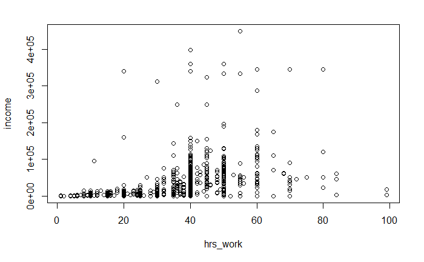

Yes, working more hours usually leads to higher income, but it’s not a certainty.

Correlation only informs us about linear association. It says nothing about the nature of the association other than “positive” or “negative”. How much can income be expected to increase for each additional hour worked? That’s a question answered by regression.

## Code Along 7

Is age associated with income? Calculate the correlation and a 95% confidence interval. Also plot the data.

Add a new R code chunk by pressing *Ctrl+Alt+I* (Win/Linux) or *Cmd+Option+I* (Mac).

## Comparing more than two means

Does mean income change according to education? Recall education has three levels.

```r
table(acs12$edu)
```

```
    college        grad hs or lower
        359         144        1439
```

The mean income for all three levels of education can be calculated using aggregate.

| edu | income |
| --- | --- |
| college | 35330.84 |
| grad | 68298.82 |
| hs or lower | 14092.83 |

They sure appear different. But these are just estimates. Maybe another sample would yield different results. A formal test for the equality of means is the One-Way Analysis of Variance, or one-way ANOVA. We can run a one-way ANOVA in R using the `aov` function. It helps to save the result and call the `summary` function on the saved object.

```r
summary(aov1)
```

```
              Df    Sum Sq   Mean Sq F value Pr(>F)
edu            2 4.383e+11 2.192e+11   115.3 <2e-16 ***
Residuals   1620 3.079e+12 1.901e+09
---
Signif. codes:  0 ‘***’ 0.001 ‘**’ 0.01 ‘*’ 0.05 ‘.’ 0.1 ‘ ’ 1
377 observations deleted due to missingness
```

The output is called an ANOVA table. The small p-value tells us the probability of seeing means that differ more so than these 3 means, assuming they’re really all equal in the population, is virtually 0. That’s all it says. It doesn’t tell us how they differ or in what direction. To investigate that we usually follow-up with what are usually called post-hoc tests.

One built-in to R that works with `aov` objects is `TukeyHSD`. That stands for Tukey’s Honestly Significant Differences. Just use it with the saved `aov` object. It calculates pairwise differences and tests if they’re plausibly different from 0, using *adjusted p-values*, (ie, larger p-values due to performing more than one hypothesis test). All of these differences appear to be quite large and quite real.

```r
TukeyHSD(aov1)
```

```
  Tukey multiple comparisons of means
    95% family-wise confidence level

Fit: aov(formula = income ~ edu, data = acs12)

$edu
                         diff       lwr       upr p adj
grad-college         32967.98  22880.03  43055.94     0
hs or lower-college -21238.01 -27440.63 -15035.38     0
hs or lower-grad    -54205.99 -63259.79 -45152.19     0
```

An exploratory plot that often accompanies a one-way ANOVA is the boxplot.

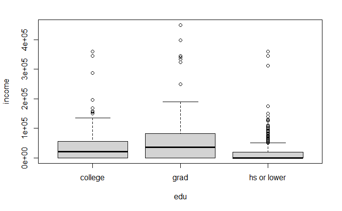

- The width of the box (along the y axis) represents the middle 50% of the data. It is called the Interquartile Range (IQR).
- The line in the box is the median.
- The top of the box is the 75th percentile.
- The bottom of the box is the 25th percentile.
- The “whiskers” extending out of the box are to the highest and lowest values not to exceed 1.5 * IQR
- The dots are considered “outliers” relative to the rest of the data.

We no doubt have some very large income values driving those means!

## Code Along 8

How does mean income differ between race? Do the following:

- calculate mean income by race using `aggregate`
- create a boxplot of income by race using `boxplot`
- Run a one-way anova using `aov`
- Compare means using `TukeyHSD`

Add a new R code chunk by pressing *Ctrl+Alt+I* (Win/Linux) or *Cmd+Option+I* (Mac).

## Checking ANOVA assumptions and performing transformations

When we run a one-way ANOVA we make some important assumptions, two of which are:

- the variance of the numeric variable is about the same between the groups
- the residuals are normally distributed. The residual is the difference between the group mean and the observed value in that group.

A quick way to visually assess these assumptions is to call `plot` on your `aov` object. This produces 4 plots. The 1st and 3rd assess the constant variance assumption. The 2nd assesses the normality assumption. The 4th assesses influential data (data that by itself is influencing the results.)

The two plots of interest to us are the 2nd and 3rd plots. They reveal pretty severe violations of the constant variance and normality assumptions. In the 2nd plot we’d like the points to lie close to the diagonal line. In the 3rd plot, we’d like the smooth red line to be close to horizontal.

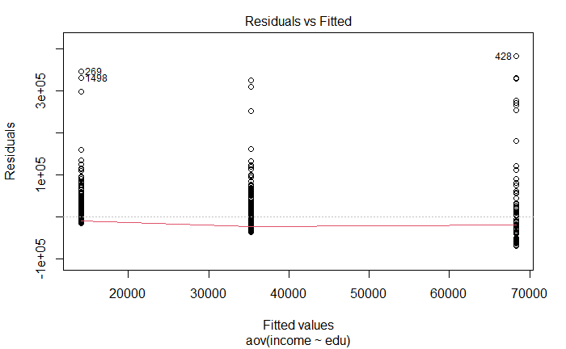

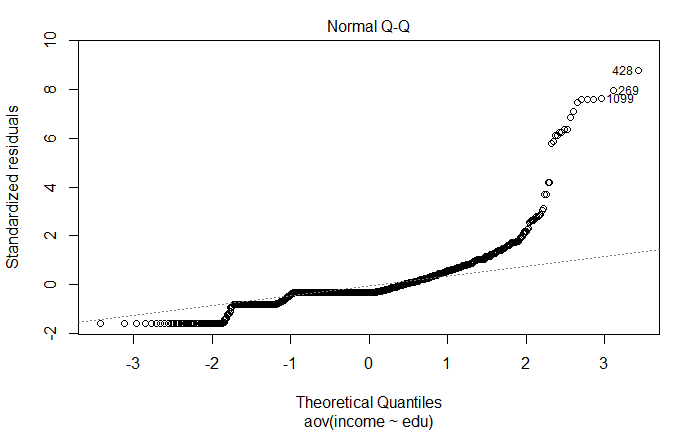

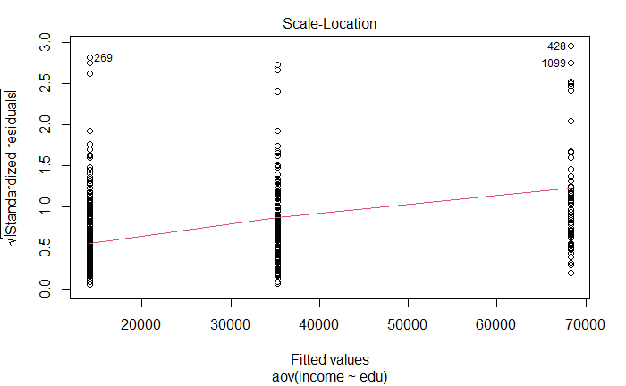

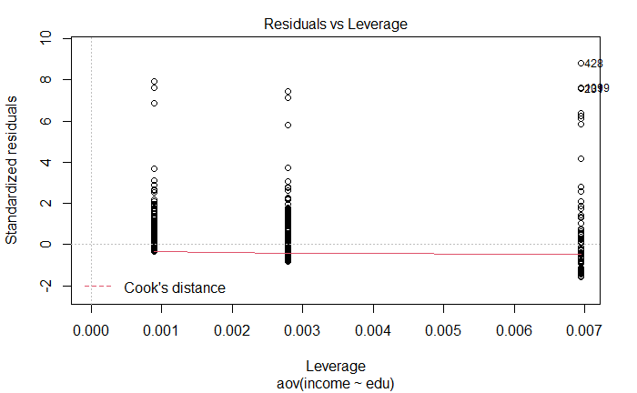

What does this mean? *It usually means our “model” is deficient in some way*. A one-way ANOVA is basically a model that says (in our case) mean income can be explained by education. If we know someone’s education level we can make a good estimate of their expected income. The violation of the assumptions tells us there are probably other factors that affect income and that our model is too simple.

What can we do if we want to still use the one-way ANOVA? A common approach is to *log transform* the numeric data and see if that helps. A log transformation is a non-linear transformation the sometimes makes data a little more symmetric. It only works on positive numbers, so we’ll need to subset our data to only use income greater than 0. Fortunately we can do all this on-the-fly in R using the `log` and `subset` functions. So now our analysis is slightly different. We’re only comparing mean incomes for people who earn more than 0. And as we’ll see, the interpretation is more complicated.

```r
summary(aov2)
```

```
             Df Sum Sq Mean Sq F value Pr(>F)
edu           2  172.7   86.33   48.64 <2e-16 ***
Residuals   891 1581.4    1.77
---
Signif. codes:  0 ‘***’ 0.001 ‘**’ 0.01 ‘*’ 0.05 ‘.’ 0.1 ‘ ’ 1
```

The p-value is quite small, which provides evidence the means really are different in some way. Let’s re-check our assumptions. They are vastly improved.

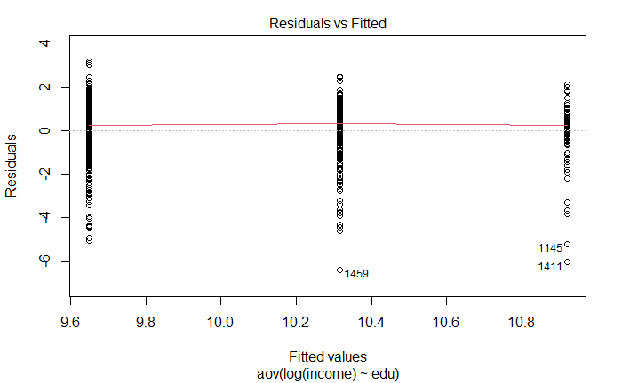

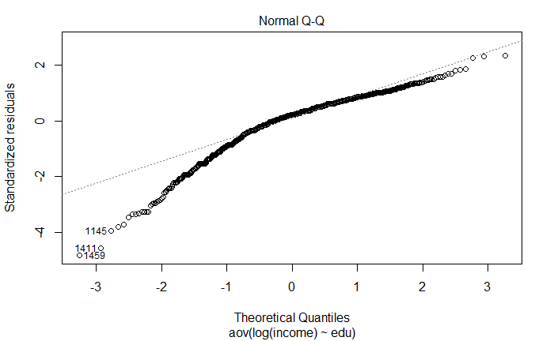

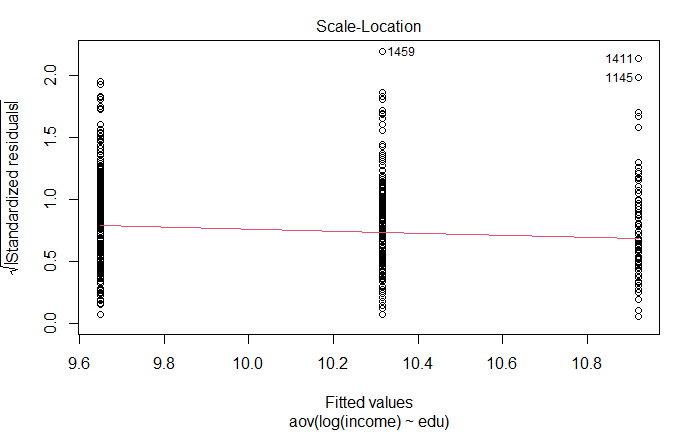

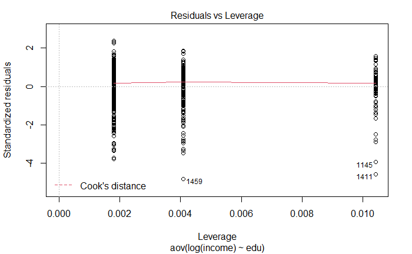

How about the post-ANOVA pairwise differences?

```r
TukeyHSD(aov2)
```

```
  Tukey multiple comparisons of means
    95% family-wise confidence level

Fit: aov(formula = log(income) ~ edu, data = subset(acs12, income > 0))

$edu
                          diff        lwr        upr    p adj
grad-college         0.6040127  0.2271993  0.9808260 0.000524
hs or lower-college -0.6662453 -0.9065537 -0.4259368 0.000000
hs or lower-grad    -1.2702579 -1.6160249 -0.9244909 0.000000
```

They appear to be significantly different, but they’re on the log scale and impossible to interpret meaningfully. Log transforming a numeric variable when doing ANOVA implies the effect of group is multiplicative instead of additive. To see that multiplicative effect we need to exponentiate the results. We can do this by saving the `TukeyHSD` result and transforming the log values using the `exp` function.

```r
exp(t.out$edu[,1:3])
```

```
                         diff       lwr       upr
grad-college        1.8294450 1.2550799 2.6666581
hs or lower-college 0.5136335 0.4039138 0.6531576
hs or lower-grad    0.2807592 0.1986869 0.3967334
```

“grad - college” equals about 1.83. This says we can expect someone with a graduate degree to make about 83% more than a person with a bachelor’s (college) degree. Likewise, “hs or lower - grad” equals about 0.28 says we can expect someone with a HS or lower education to make about 72% less than someone with a graduate degree. Or we might say someone with a HS or lower education earns about 28 cents for every dollar someone with a graduate degree earns.

## Simple linear regression

Income has a lot of variability. Why is that? Could some of the variability be due to age of the person? Simple linear regression attempts to answer this question. It allows us to estimate a mean conditional on some other numeric variable. We call it “simple” because we just use one variable. Using more than one variable is often called “Multiple Regression”. In statistics this is more commonly referred to as “Linear Modeling”.

Whole courses are taught on this topic. Entire books are devoted to it. We can’t possibly do it justice, but we can get you started with some basics.

Linear regression is performed in R with the `lm` function. Like the `t.test` function it uses the formula interface. (In fact a t-test is simply a special case of regression.) Like `aov`, it’s common practice to save the result of `lm` and use `summary` to view the results.

Below we might read the formula as “regress income on age”.

```r
summary(m1)
```

```
Call:
lm(formula = income ~ age, data = acs12)

Residuals:
   Min     1Q Median     3Q    Max
-26309 -22758 -20280   9719 427820

Coefficients:
            Estimate Std. Error t value Pr(>|t|)
(Intercept) 27547.55    3057.03   9.011   <2e-16 ***
age           -82.58      59.21  -1.395    0.163
---
Signif. codes:  0 ‘***’ 0.001 ‘**’ 0.01 ‘*’ 0.05 ‘.’ 0.1 ‘ ’ 1

Residual standard error: 46550 on 1621 degrees of freedom
  (377 observations deleted due to missingness)
Multiple R-squared:  0.001199,  Adjusted R-squared:  0.0005826
F-statistic: 1.945 on 1 and 1621 DF,  p-value: 0.1633
```

According to the output (if we believe it), each additional year of age results in earning about 82 fewer dollars per year. The intercept makes no sense. It is the expected mean income of someone who is age 0.

The output includes a hypothesis test for age. The null is that the *coefficient* for age is 0. In other words, age tells us nothing about income. The p-value says we have a probability of getting a coefficient less than -82 (or greater than 82) of 0.163 if in fact the coefficient really is 0. In this case we can’t tell if the *effect* of age is positive or negative. It is certainly not exactly 0!

But linear regression has the same assumptions as a one-way ANOVA. (And like the t-test, ANOVA is a special case of linear regression.) We should assess the assumptions before drawing conclusions from our results.

Call `plot` on the `lm` object to assess the assumptions graphically. The qq-plot (#2) is pretty terrible. Once again we might want to entertain a log transformation for income.

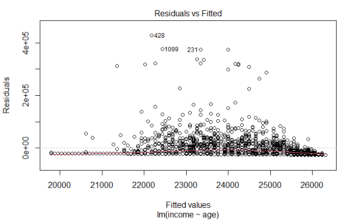

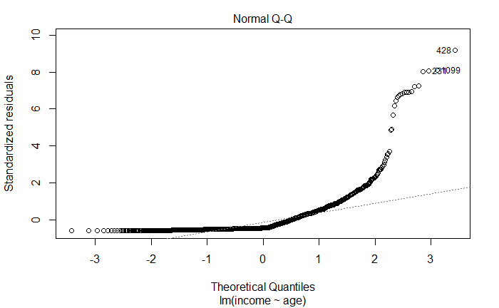

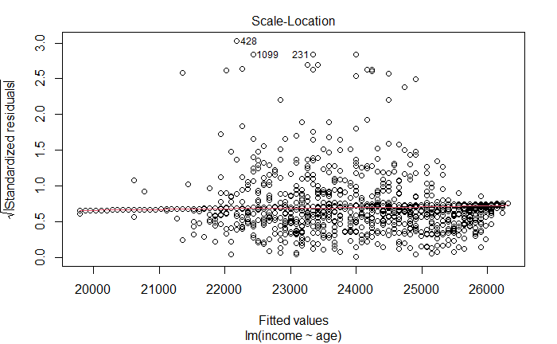

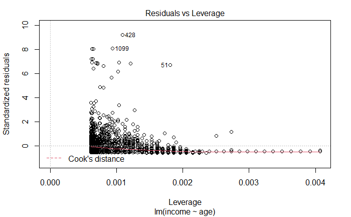

The qq-plot is much improved after running the regression on `log(income)`.

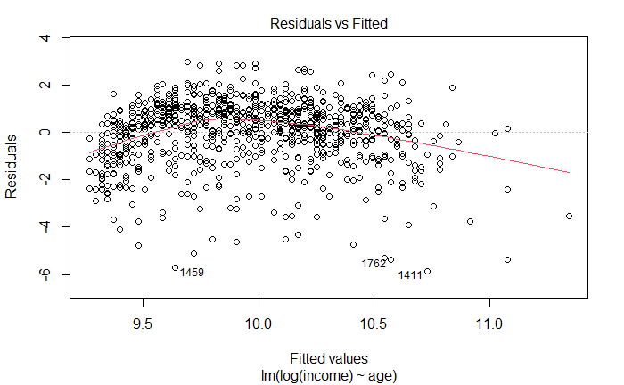

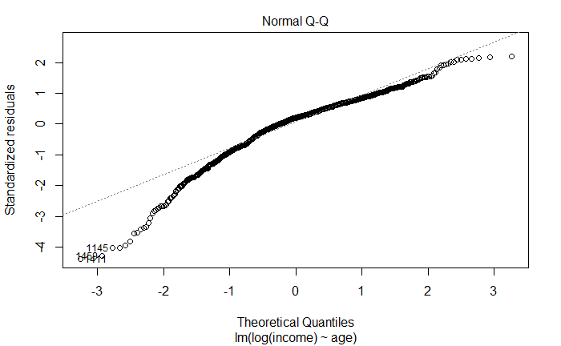

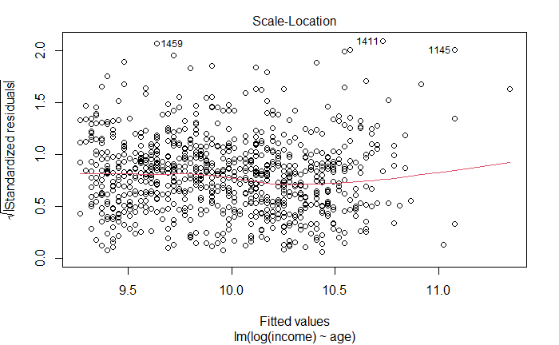

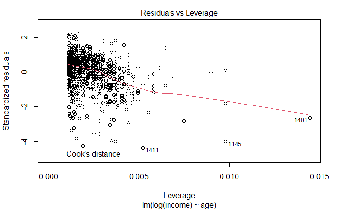

And now the effect of age seems to emerge. The coefficient and associated hypothesis test provides good evidence that it’s positive.

```r
summary(m2)
```

```
Call:
lm(formula = log(income) ~ age, data = subset(acs12, income >
    0))

Residuals:
    Min      1Q  Median      3Q     Max
-5.8641 -0.6750  0.2726  0.8831  2.9612

Coefficients:
            Estimate Std. Error t value Pr(>|t|)
(Intercept) 8.840431   0.134770   65.60   <2e-16 ***
age         0.026636   0.003003    8.87   <2e-16 ***
---
Signif. codes:  0 ‘***’ 0.001 ‘**’ 0.01 ‘*’ 0.05 ‘.’ 0.1 ‘ ’ 1

Residual standard error: 1.344 on 892 degrees of freedom
Multiple R-squared:  0.08106,   Adjusted R-squared:  0.08003
F-statistic: 78.68 on 1 and 892 DF,  p-value: < 2.2e-16
```

Because income is log transformed the regression output is harder to understand. We need to exponentiate the coefficient to get the multiplicative effect. Extract the coefficient with the `coef` function and then exponentiate.

```r
exp(coef(m2))
```

```
(Intercept)         age
6907.970716    1.026994
```

According to the output (if we believe it), each additional year of age increases income by about 3%. The intercept again makes no sense.

Is this model “good”? The Adjusted R-squared provides some indication of how well this model explains the variability in `log(income)`. It explains about 8% of the variability. Depending on past research and/or your field of study, 8% may be good or bad.

We can visualize simple linear regression using the `abline` function.

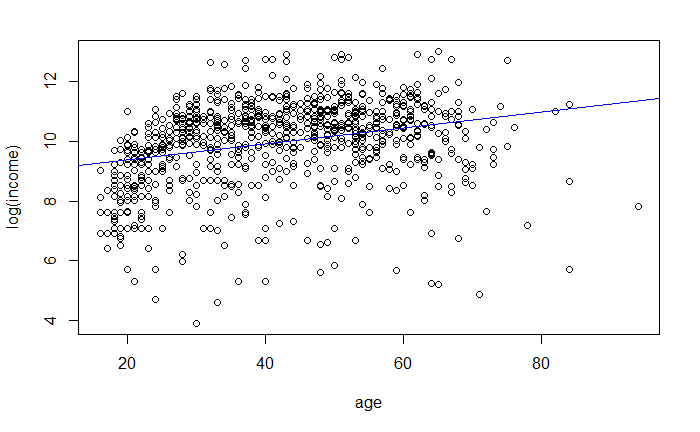

There is some association of age with income, but not a lot. The blue prediction line implies you would expect to earn the most money in your 80s and 90s.

The association appears to increase in the 20s and 30s but level off after that. This makes sense. We wouldn’t expect income to increase indefinitely with age. One very simple way to accommodate this non-linear association is with a polynomial function. For example: income = age + age^2 + age^3. The `poly` function makes this rather easy to do. The second argument is the degree of the polynomial.

```r
summary(m3)
```

```
Call:
lm(formula = log(income) ~ poly(age, degree = 3), data = subset(acs12,
    income > 0))

Residuals:
    Min      1Q  Median      3Q     Max
-5.9084 -0.5713  0.2074  0.7807  3.1639

Coefficients:
                        Estimate Std. Error t value Pr(>|t|)
(Intercept)              9.96741    0.04195 237.574  < 2e-16 ***
poly(age, degree = 3)1  11.92420    1.25445   9.506  < 2e-16 ***
poly(age, degree = 3)2 -14.08304    1.25445 -11.226  < 2e-16 ***
poly(age, degree = 3)3   3.61262    1.25445   2.880  0.00407 **
---
Signif. codes:  0 ‘***’ 0.001 ‘**’ 0.01 ‘*’ 0.05 ‘.’ 0.1 ‘ ’ 1

Residual standard error: 1.254 on 890 degrees of freedom
Multiple R-squared:  0.2016,    Adjusted R-squared:  0.1989
F-statistic: 74.89 on 3 and 890 DF,  p-value: < 2.2e-16
```

The Adjusted R-Squared has more than doubled to about 0.20. Still not great, but better. The diagnostic plots are largely unchanged if not slightly better.

Let’s plot the prediction line. One way to do this is with the `predict` function. Just give it a model object name and the range of data on which to make a prediction using the `newdata` argument. Notice the new data needs to be in a data.frame. Finally we add the predicted line to the plot using the `lines` function.

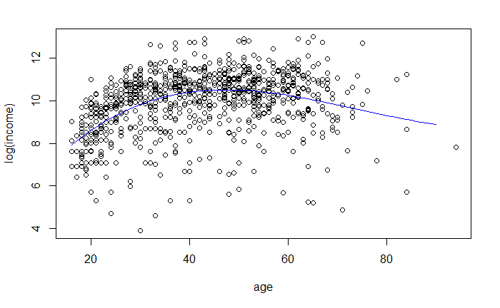

This “model” seems better at capturing the relationship between age and income. What is the expected mean income for ages 25, 30, 35, 40, 45, and 50?

```r
# don't forget to use exp() to get dollar amounts
predict(m3, newdata = data.frame(age = seq(25,50,5))) %>%
  exp()
```

```
       1        2        3        4        5        6
10987.20 18404.96 26356.39 32847.44 36269.66 36122.12
```

To get 95% confidence intervals for these predicted means, set `interval = "confidence"`.

```r
predict(m3, newdata = data.frame(age = seq(25,50,5)),
        interval = "confidence") %>%
  exp()
```

```
       fit       lwr      upr
1 10987.20  9613.762 12556.85
2 18404.96 16191.503 20921.01
3 26356.39 23117.932 30048.51
4 32847.44 29009.583 37193.04
5 36269.66 32352.735 40660.81
6 36122.12 32246.803 40463.16
```

There is MUCH MORE to regression and linear modeling. In real life we would probably model income by several predictors, such as education, gender, geographic location, etc.

## We’re done!

If you would like to talk more about statistics or need statistical help with your research, I would love to hear from you: `jcf2d@virginia.edu` or `statlab@virginia.edu`